# Changeset Analysis

Part 0: Define custom functions

Part 0.1: Load Libraries

## Part 1: Load the Data

1. Load the entire Data from the disaster window CSV
2. Load some small sample data, this is data from 25 random users in each data set.
3. For more data, load a larger sample: 75 users from each set.
4. Load only changesets with less than 1000 nodes (still has the 1 node)
5. Load only changesets with less than 10000 nodes (and more than 1 node) – entire set

### Summary Statistics of the data

*Currently not implemented*

Philippines

Haiti

## Part 2. Visual Comparison

### Comparing Node Counts

Notice that there is a large spike in the Philippines at 4 nodes per changeset. A simple building is typically comprised of exaclty 4 nodes. The working hypothesis here is that each of these changesets represents a building and that buildings were mapped in the Philippines because the road structure was already in place; whereas in Haiti, the road system was not yet in place.

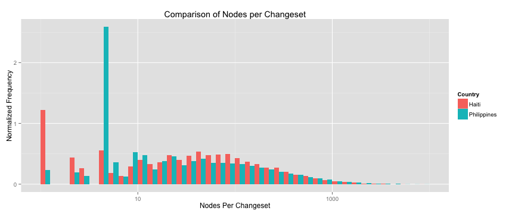

### Lorenz curves for the amount of nodes

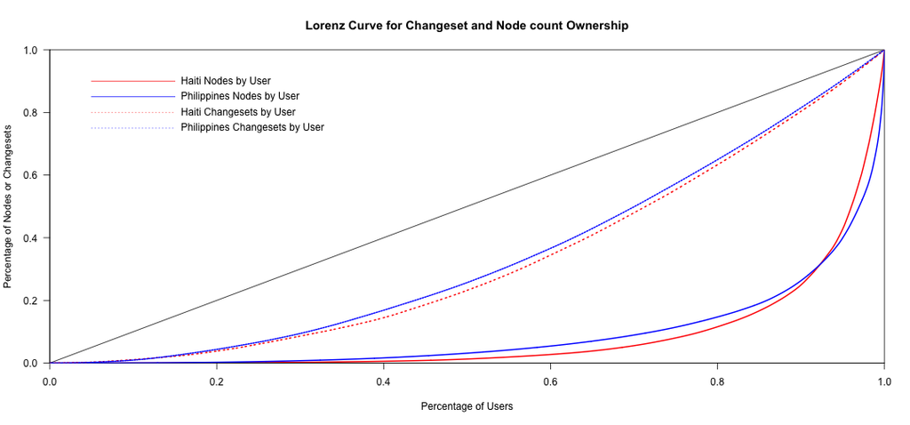

### Count users that edited in both sets:

```
## [1] 54
```

### Plot User contributions by day since the event

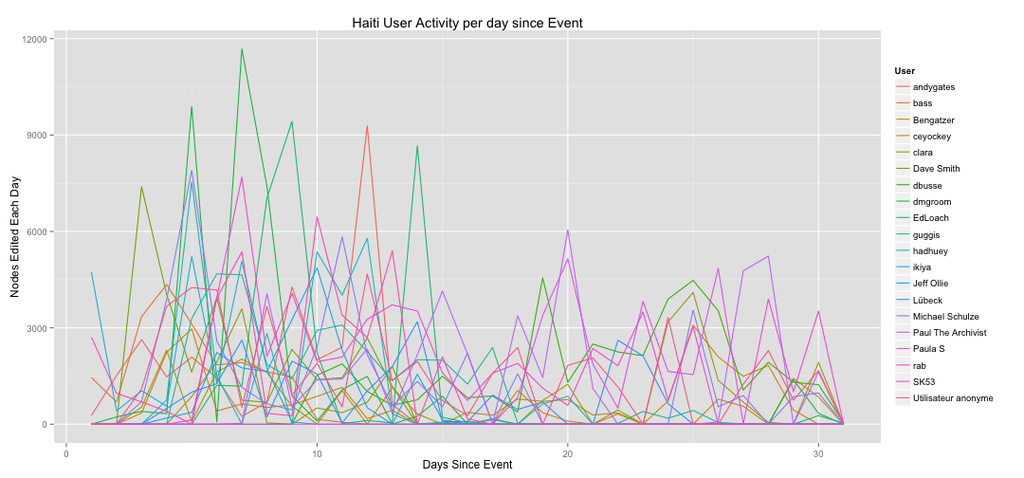

```r
# Load the CSV that's printed from ruby
haiti_by_day_contributions = read.csv("/Users/jenningsanderson/osm-history/ruby/csv_exports/haiti_top_20_user_node_count_by_day.csv")
ggplot(haiti_by_day_contributions, aes(x = DaysSinceEvent, y = NodeCount, color = User)) +
    geom_line() + scale_fill_brewer(palette = "Paired") + xlab("Days Since Event") +
    ylab("Nodes Edited Each Day") + ggtitle("Haiti User Activity per day since Event")
```

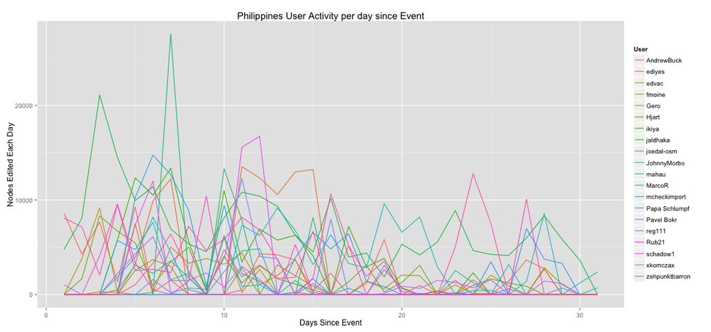

```r
# Load the CSV that's printed from ruby
phil_by_day_contributions = read.csv("/Users/jenningsanderson/osm-history/ruby/csv_exports/phil_top_20_user_node_count_by_day.csv")
ggplot(phil_by_day_contributions, aes(x = DaysSinceEvent, y = NodeCount, color = User)) +
    geom_line() + scale_fill_brewer(palette = "Blues") + xlab("Days Since Event") +
    ylab("Nodes Edited Each Day") + ggtitle("Philippines User Activity per day since Event")
```

### User contribution charts

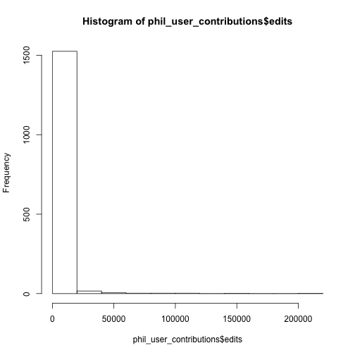

```r
phil_user_contributions  = read.csv("/Users/jenningsanderson/osm-history/ruby/csv_exports/edits_per_user_philippines.csv")
haiti_user_contributions = read.csv("/Users/jenningsanderson/osm-history/ruby/csv_exports/edits_per_user_haiti.csv")

hist(phil_user_contributions$edits)
```

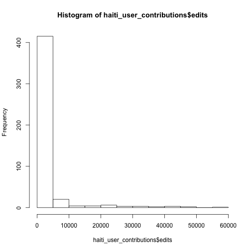

```r
hist(haiti_user_contributions$edits)
```

```r
png("/Users/jenningsanderson/Dropbox/OSM_Behavioral_Analysis_CSCW/Images/user_edits_philippines.png", width=800, height=400)
plot(y=(sort(phil_user_contributions$edits, decreasing=T)), x=seq(1,length(phil_user_contributions$user)), pch=20,
     log='y', xlab="Individual Users", ylab="Number of Edits", main="Philippines: Number of Edits per user",
     cex.main=2, cex.axis=1.2, cex.lab=1.2)
abline(h=median(phil_user_contributions$edits),col=4,lty=2)
abline(h=mean(phil_user_contributions$edits),col=2,lty=2)
legend("topright",#x=380,y=50000,      # places a legend at the appropriate place
         c("Mean","Median"),  # puts text in the legend
       lty=c(2,2),        # gives the legend appropriate symbols
       col=c(2,4),
       cex=1.3)
dev.off()
```

```r
png("/Users/jenningsanderson/Dropbox/OSM_Behavioral_Analysis_CSCW/Images/user_edits_haiti.png", width=800, height=400)
plot(y=(sort(haiti_user_contributions$edits, decreasing=T)), x=seq(1,length(haiti_user_contributions$user)), pch=20,
     log='y', xlab="Individual Users", ylab="Number of Edits", main="Haiti: Number of Edits per user",
     cex.main=2, cex.axis=1.2, cex.lab=1.2)
abline(h=median(haiti_user_contributions$edits),col=4,lty=2)
abline(h=mean(haiti_user_contributions$edits),col=2,lty=2)
legend("topright",#x=380,y=50000,      # places a legend at the appropriate place
         c("Mean","Median"),  # puts text in the legend
       lty=c(2,2),        # gives the legend appropriate symbols
       col=c(2,4),
       cex=1.3)
dev.off()
```

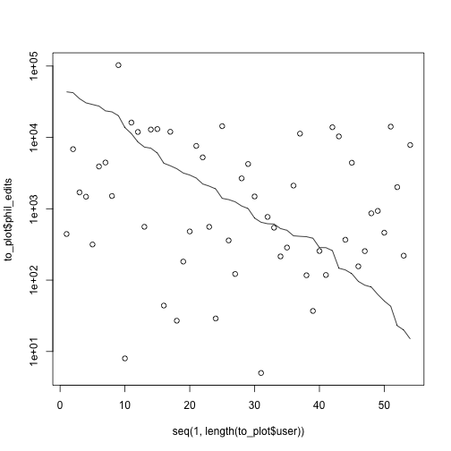

```r
users_in_both <- intersect(haiti_user_contributions$user, phil_user_contributions$user)

haiti_intersect <-haiti_user_contributions[haiti_user_contributions$user %in% users_in_both,]
phil_intersect <-phil_user_contributions[phil_user_contributions$user %in% users_in_both,]

sorted_haiti_intersect <- with(haiti_intersect,  haiti_intersect[order(user),])
sorted_phil_intersect  <- with(phil_intersect, phil_intersect[order(user),])

sorted_haiti_intersect$phil_edits = sorted_phil_intersect$edits

#Now sort it by a different column
to_plot <- with(sorted_haiti_intersect, sorted_haiti_intersect[order(-edits),])

plot(x=seq(1,length(to_plot$user)), y=to_plot$phil_edits, log='y')
lines(x=seq(1,length(to_plot$user)), y=to_plot$edits)
```

```r
#mean(haiti_intersect$edits)
#mean(phil_intersect$edits)
```